```r
library(tidycensus)
library(tidyverse)
library(ggplot2)
library(ggthemes)
library(viridis)
```

### I am loading my data set from assignment 1:

This data set includes the following variables: 1. Sex, “SEX”, categorical 2. Wages or salary income past 12 months, “WAGP”, continuous 3. Public assistance income past 12 months, “PAP”, continuous 4. Educational attainment, “SCHL”, categorical 5. Citizenship status, CIT, categorical 6. Age, AGEP, continuous

I am interested in evaluating the relationships that exist between Sex, Immigration Status, and Educational Achievement. I am filtering my data to only include Wages and Public Assistance Income greater than -1 (thank you Sara for showing me how to do this!)

```r
person_data <-read_csv('SaraArman-DataSet1_Final.csv') %>%
  filter(WAGP> -1 & PAP> -1)
```

###For all possible pairs of variables in your dataset, test the relationship between the two variables. Indicate the significance and (if appropriate) the magnitude of each relationship.

The first variable I will test is Wages Over Past 12 Months (WAGP) I will test the relationship between WAGP and my other continous variables (PAP,AGEP)

For both of these, the p value is less than .05, so these have a statistically significant relationship, though we can see that is a weak negative correlation at 95% confidence interval.

What I interperet this to mean, is that people who have received wages over the past 12 months are slightly less likely to receive public assistance income, and that older people make slightly less money than younger people do.

```r
correlation <- cor.test(person_data$WAGP, person_data$PAP)
correlation
```

```
##
##  Pearson's product-moment correlation
##
## data:  person_data$WAGP and person_data$PAP
## t = -5.0376, df = 59957, p-value = 4.729e-07
## alternative hypothesis: true correlation is not equal to 0
## 95 percent confidence interval:
##  -0.02856835 -0.01256656
## sample estimates:
##         cor
## -0.02056877
```

### Scatter Plot of Wage and Public Assistance Income

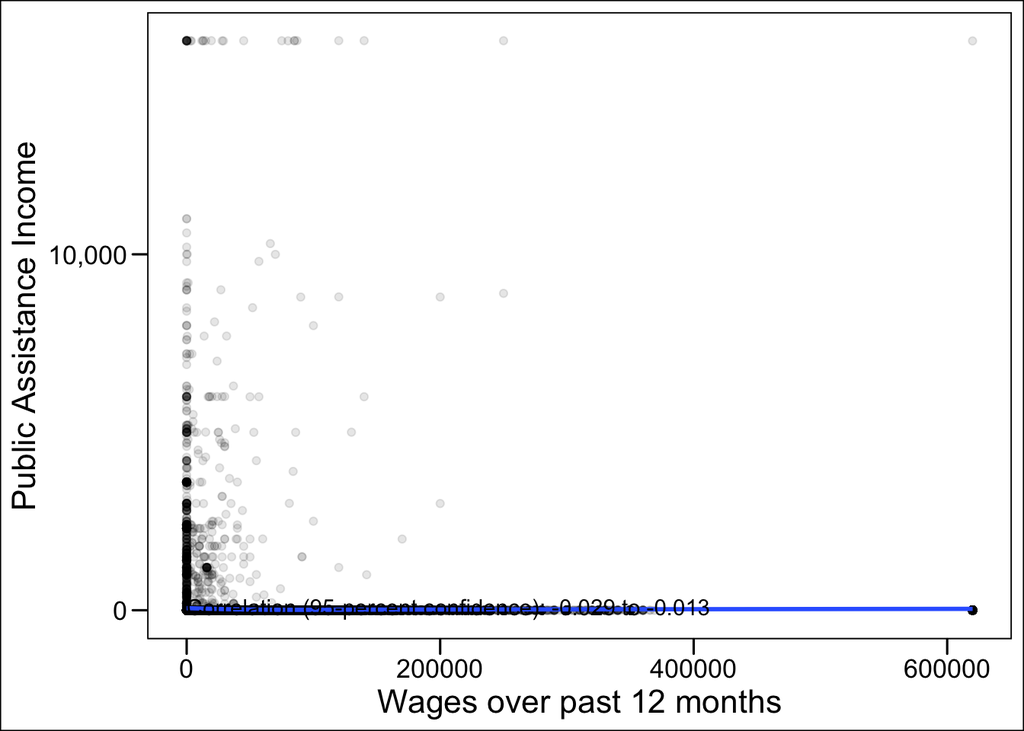

```r
options(scipen = 999)
ggplot(person_data, aes(x = WAGP, y = PAP)) +
  geom_point(size = 1.5, alpha = 0.10, position = "jitter") +
  geom_smooth() +
  theme_base() +
  scale_x_continuous(name = "Wages over past 12 months") +
  scale_y_continuous(name = "Public Assistance Income",
                     breaks = seq(0, 40000, by = 10000),
                     labels = paste(
                                    prettyNum(seq(0, 40000, by = 10000),
                                              big.mark = ","))) +
  annotate(geom = "text", x = 0, y = 100,
           label = paste("Correlation (95-percent confidence):",
                         prettyNum(correlation$conf.int[1], digits = 2),
                         "to",
                         prettyNum(correlation$conf.int[2], digits = 2)),
           hjust = 0)
```

```r
correlation <- cor.test(person_data$WAGP, person_data$AGEP)
correlation
```

```
##
##  Pearson's product-moment correlation
##
## data:  person_data$WAGP and person_data$AGEP
## t = -8.002, df = 59957, p-value = 0.000000000000001246
## alternative hypothesis: true correlation is not equal to 0
## 95 percent confidence interval:
##  -0.04065587 -0.02466438
## sample estimates:
##         cor
## -0.03266222
```

### Scatter Plot of Wage and Age

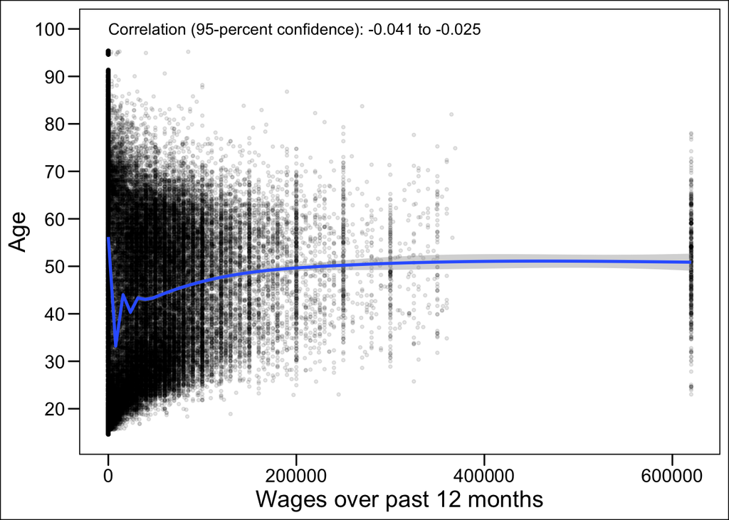

```r
options(scipen = 999)
ggplot(person_data, aes(x = WAGP, y = AGEP)) +
  geom_point(size = .8, alpha = 0.10, position = "jitter") +
  geom_smooth() +
  theme_base() +
  scale_x_continuous(name = "Wages over past 12 months") +
  scale_y_continuous(name = "Age",
                     breaks = seq(0, 100, by = 10),
                     labels = paste(
                                    prettyNum(seq(0, 100, by = 10),
                                              big.mark = ","))) +
  annotate(geom = "text", x = 0, y = 100,
           label = paste("Correlation (95-percent confidence):",
                         prettyNum(correlation$conf.int[1], digits = 2),
                         "to",
                         prettyNum(correlation$conf.int[2], digits = 2)),
           hjust = 0)
```

### I will now test the relationship between WAGP and my categorical variables (Sex, Educational Attainment, and Citizenship Status)

The first test i will run will be a t-test for Wages (Continous variable) and Sex (Binary categorical Variable)A question to ask with these variables would be “do men make more or less than women in Massachusetts”

Sex and Wages are strongly and positively correlated at a 95% CI. I interpret this to mean that people who identified as Male, on average, make more than people who have identified as Female. I am creating a violin plot to show the results.

```r
difference = t.test(WAGP ~ SEX_label == "Female",
                    data = person_data)
difference
```

```
##
##  Welch Two Sample t-test
##
## data:  WAGP by SEX_label == "Female"
## t = 35.195, df = 45849, p-value < 0.00000000000000022
## alternative hypothesis: true difference in means is not equal to 0
## 95 percent confidence interval:
##  19278.85 21552.80
## sample estimates:
## mean in group FALSE  mean in group TRUE
##            50928.63            30512.80
```

[figure not shown]

```r
ggplot(person_data, aes(x = SEX_label, y = WAGP)) +
  geom_violin() +
  theme_bw() +
  scale_x_discrete(name = "Sex Assigned: Male or Female",
                   labels = c("Male", "Female")) +
   scale_y_continuous(name = "Wages Over Past 12 Months",
                     breaks = seq(0, 50000, by = 2000),
                     labels = paste("$",
                                    prettyNum(seq(0, 50000, by = 2000),
                                              big.mark = ","))) +
  annotate(geom = "text", x = 3, y = 50000, size = 3,
           label = paste("Difference in means\n(95% confidence):\n$",
                         prettyNum(abs(difference$conf.int[2]),
                                   digits = 0), " to $",
                         prettyNum(abs(difference$conf.int[1]),
                                   digits = 0),
                         sep = "")) +
  annotate(geom = "text", x = 1, y = difference$estimate[1], size = 3,
           label = paste("Mean (95% confidence):\n$",
                         prettyNum(difference$estimate[1], digits = 0))) +
  annotate(geom = "text", x = 2, y = difference$estimate[2], size = 3,
           label = paste("Mean (95% confidence):\n$",
                         prettyNum(difference$estimate[2], digits = 0)))
```

For WAGP and my categorical variables with more than 2 options, I will run the anova test. I see that there is p value less than .05, so these Wages are is positively correlated with Citizenship Status and Educational Attainment. I will depict my results with a box plot.

```r
anova <- aov(WAGP ~ SCHL_label, data = person_data)
summary(anova)
```

```
##                Df          Sum Sq       Mean Sq F value              Pr(>F)
## SCHL_label     23  42223497447805 1835804236861   433.6 <0.0000000000000002 ***
## Residuals   59935 253756420531408    4233860358
## ---
## Signif. codes:  0 '***' 0.001 '**' 0.01 '*' 0.05 '.' 0.1 ' ' 1
```

```r
anova <- aov(WAGP ~ CIT_label, data = person_data)
summary(anova)
```

```
##                Df          Sum Sq      Mean Sq F value              Pr(>F)
## CIT_label       4    577573741769 144393435442   29.31 <0.0000000000000002 ***
## Residuals   59954 295402344237435   4927149886
## ---
## Signif. codes:  0 '***' 0.001 '**' 0.01 '*' 0.05 '.' 0.1 ' ' 1
```

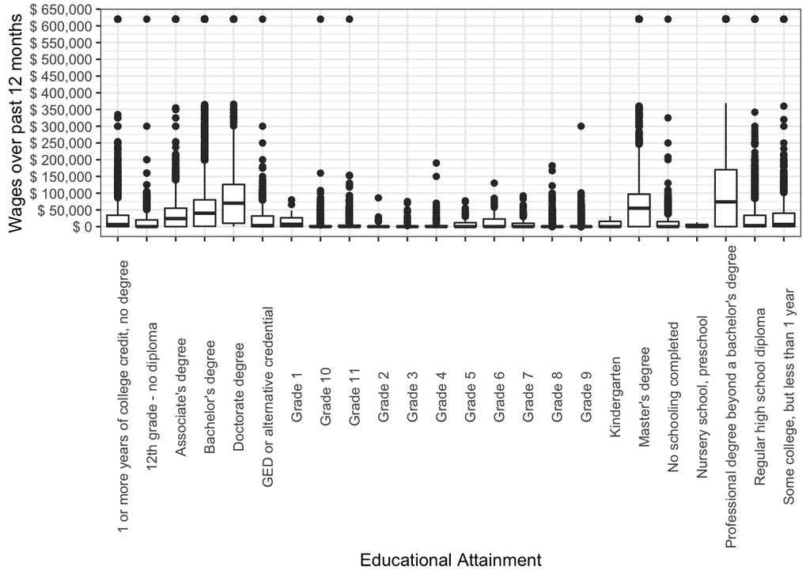

```r
ggplot(person_data, aes(x = SCHL_label, y = WAGP)) +
  geom_boxplot() +
  theme_bw() +
  theme(axis.text.x = element_text(angle = 90)) +
  scale_x_discrete(name = "Educational Attainment") +
  scale_y_continuous(name = "Wages over past 12 months",
                     breaks = seq(0, 700000, by = 50000),
                     labels = paste("$",
                                    prettyNum(seq(0, 700000, by = 50000),
                                              big.mark = ",")))
```

```r
coord_flip()
```

[output not shown]

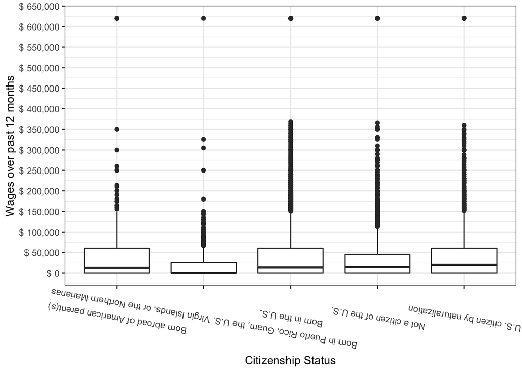

```r
ggplot(person_data, aes(x = CIT_label, y = WAGP)) +
  geom_boxplot() +
  theme_bw() +
  theme(axis.text.x = element_text(angle = 170)) +
  scale_x_discrete(name = "Citizenship Status") +
  scale_y_continuous(name = "Wages over past 12 months",
                     breaks = seq(0, 800000, by = 50000),
                     labels = paste("$",
                                    prettyNum(seq(0, 800000, by = 50000),
                                              big.mark = ",")))
```

## The Second Variable I will test is Sex

Sex and Continous Variables:

```r
difference = t.test(PAP ~ SEX_label == "Female",
                    data = person_data)
difference
```

```
##
##  Welch Two Sample t-test
##
## data:  PAP by SEX_label == "Female"
## t = -4.2369, df = 59891, p-value = 0.00002269
## alternative hypothesis: true difference in means is not equal to 0
## 95 percent confidence interval:
##  -26.224762  -9.635739
## sample estimates:
## mean in group FALSE  mean in group TRUE
##            30.20838            48.13863
```

```r
difference = t.test(AGEP~ SEX_label == "Female",
                    data = person_data)
difference
```

```
##
##  Welch Two Sample t-test
##
## data:  AGEP by SEX_label == "Female"
## t = -12.977, df = 59866, p-value < 0.00000000000000022
## alternative hypothesis: true difference in means is not equal to 0
## 95 percent confidence interval:
##  -2.433021 -1.794499
## sample estimates:
## mean in group FALSE  mean in group TRUE
##            46.68251            48.79627
```

Sex and Categorical Variables:

I will now test sex and educational attainment. Since educational attainment is a categorical variable I will use a chi-square test. I can see that both of my p values are really small, so there is a significant relationship between sex and Education. there is also a significant relationship between sex and citizenship status which I was not expecting. I will depict these in a jitterplot which I got off the ggplot cheat code. There is not much I can interpret from the plot, perhaps that women are more likely to have an associate degree than men are.

```r
chi_sq <- chisq.test(person_data$SEX_label, person_data$SCHL_label)
chi_sq
```

```
##
##  Pearson's Chi-squared test
##
## data:  person_data$SEX_label and person_data$SCHL_label
## X-squared = 474.5, df = 23, p-value < 0.00000000000000022
```

```r
chi_sq <- chisq.test(person_data$SEX_label, person_data$CIT_label)
chi_sq
```

```
##
##  Pearson's Chi-squared test
##
## data:  person_data$SEX_label and person_data$CIT_label
## X-squared = 28.062, df = 4, p-value = 0.00001212
```

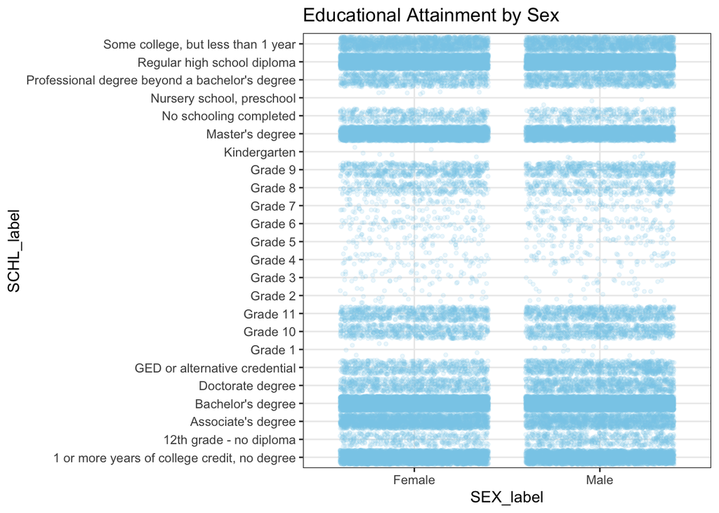

```r
ggplot(person_data, aes(x = SEX_label, y = SCHL_label)) +
geom_jitter(size = 1, alpha = 0.15, color = "skyblue")+
  labs(title = 'Educational Attainment by Sex')+
 theme_bw()
```

```r
coord_flip()
```

[output not shown]

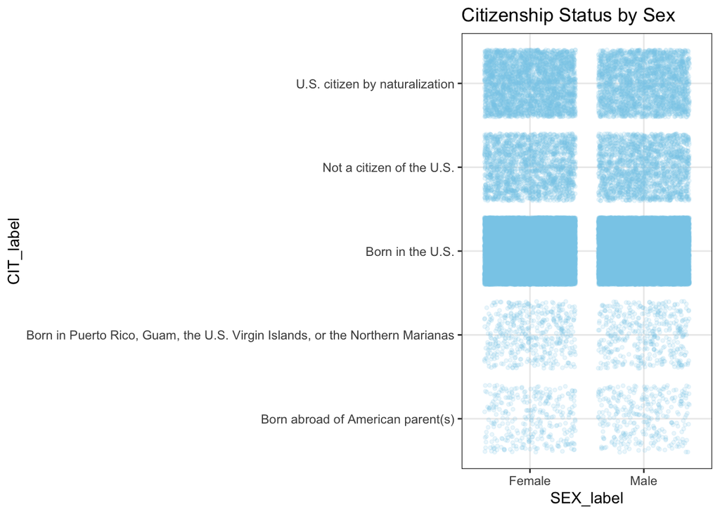

```r
ggplot(person_data, aes(x = SEX_label, y = CIT_label)) +
geom_jitter(size = 0.95, alpha = 0.15, color = "skyblue")+
  labs(title = 'Citizenship Status by Sex')+
 theme_bw()
```

```r
coord_flip()
```

[output not shown]

### My third variable is Public Assistance Income

I will first test Public Assistance Income with Age a continous variable. I see there is a significant relationship, and they are weakly correlated.

```r
correlation <- cor.test(person_data$PAP, person_data$AGEP)
correlation
```

```
##
##  Pearson's product-moment correlation
##
## data:  person_data$PAP and person_data$AGEP
## t = 2.7977, df = 59957, p-value = 0.005148
## alternative hypothesis: true correlation is not equal to 0
## 95 percent confidence interval:
##  0.003421125 0.019427604
## sample estimates:
##       cor
## 0.0114251
```

I will test Public Assistance Income with my categorical variables, Educational Attainment and Citizenship Status.

These are significant relationships that are weakly and positively correlated.

```r
anova <- aov(PAP ~ SCHL_label, data = person_data)
summary(anova)
```

```
##                Df      Sum Sq Mean Sq F value              Pr(>F)
## SCHL_label     23    56657976 2463390   9.126 <0.0000000000000002 ***
## Residuals   59935 16177612658  269919
## ---
## Signif. codes:  0 '***' 0.001 '**' 0.01 '*' 0.05 '.' 0.1 ' ' 1
```

```r
anova <- aov(PAP ~ CIT_label, data = person_data)
summary(anova)
```

```
##                Df      Sum Sq Mean Sq F value         Pr(>F)
## CIT_label       4    13505262 3376315   12.48 0.000000000379 ***
## Residuals   59954 16220765373  270554
## ---
## Signif. codes:  0 '***' 0.001 '**' 0.01 '*' 0.05 '.' 0.1 ' ' 1
```

### My fourth variable is Educational Attainment (SCHL)

I will test educational attainment and age, a continous variable. To do this I will use the anova test. This relationship is signficiant.

```r
anova <- aov(AGEP ~ SCHL_label, data = person_data)
summary(anova)
```

```
##                Df   Sum Sq Mean Sq F value              Pr(>F)
## SCHL_label     23  1899341   82580   224.3 <0.0000000000000002 ***
## Residuals   59935 22064882     368
## ---
## Signif. codes:  0 '***' 0.001 '**' 0.01 '*' 0.05 '.' 0.1 ' ' 1
```

I will then test educational attainment and citizenship status, 2 categorical variables, so I will use a chi square test. My p value is less than .05, so I know this is a significant relationship.

```r
chi_sq <- chisq.test(person_data$CIT_label, person_data$SCHL_label)
chi_sq
```

```
##
##  Pearson's Chi-squared test
##
## data:  person_data$CIT_label and person_data$SCHL_label
## X-squared = 4257.1, df = 92, p-value < 0.00000000000000022
```

```r
chi_sq$observed
```

```
##                                                                               person_data$SCHL_label
## person_data$CIT_label                                                          1 or more years of college credit, no degree
##   Born abroad of American parent(s)                                                                                      83
##   Born in Puerto Rico, Guam, the U.S. Virgin Islands, or the Northern Marianas                                           88
##   Born in the U.S.                                                                                                     6160
##   Not a citizen of the U.S.                                                                                             427
##   U.S. citizen by naturalization                                                                                        601
##                                                                               person_data$SCHL_label
## person_data$CIT_label                                                          12th grade - no diploma
##   Born abroad of American parent(s)                                                                 13
##   Born in Puerto Rico, Guam, the U.S. Virgin Islands, or the Northern Marianas                      21
##   Born in the U.S.                                                                                 581
##   Not a citizen of the U.S.                                                                        107
##   U.S. citizen by naturalization                                                                   166
##                                                                               person_data$SCHL_label
## person_data$CIT_label                                                          Associate's degree
##   Born abroad of American parent(s)                                                            35
##   Born in Puerto Rico, Guam, the U.S. Virgin Islands, or the Northern Marianas                 62
##   Born in the U.S.                                                                           3387
##   Not a citizen of the U.S.                                                                   151
##   U.S. citizen by naturalization                                                              400
##                                                                               person_data$SCHL_label
## person_data$CIT_label                                                          Bachelor's degree
##   Born abroad of American parent(s)                                                          158
##   Born in Puerto Rico, Guam, the U.S. Virgin Islands, or the Northern Marianas                75
##   Born in the U.S.                                                                         11594
##   Not a citizen of the U.S.                                                                  743
##   U.S. citizen by naturalization                                                            1114
##                                                                               person_data$SCHL_label
## person_data$CIT_label                                                          Doctorate degree
##   Born abroad of American parent(s)                                                          19
##   Born in Puerto Rico, Guam, the U.S. Virgin Islands, or the Northern Marianas                7
##   Born in the U.S.                                                                         1043
##   Not a citizen of the U.S.                                                                 284
##   U.S. citizen by naturalization                                                            290
##                                                                               person_data$SCHL_label
## person_data$CIT_label                                                          GED or alternative credential
##   Born abroad of American parent(s)                                                                       12
##   Born in Puerto Rico, Guam, the U.S. Virgin Islands, or the Northern Marianas                            64
##   Born in the U.S.                                                                                      1170
```

[output cut: 113 more lines]

```
##   U.S. citizen by naturalization                                                                                          193
##                                                                               person_data$SCHL_label
## person_data$CIT_label                                                          Regular high school diploma
##   Born abroad of American parent(s)                                                                     91
##   Born in Puerto Rico, Guam, the U.S. Virgin Islands, or the Northern Marianas                         193
##   Born in the U.S.                                                                                    9502
##   Not a citizen of the U.S.                                                                            746
##   U.S. citizen by naturalization                                                                      1032
##                                                                               person_data$SCHL_label
## person_data$CIT_label                                                          Some college, but less than 1 year
##   Born abroad of American parent(s)                                                                            32
##   Born in Puerto Rico, Guam, the U.S. Virgin Islands, or the Northern Marianas                                 46
##   Born in the U.S.                                                                                           2947
##   Not a citizen of the U.S.                                                                                   172
##   U.S. citizen by naturalization                                                                              242
```

```r
chi_sq$expected
```

```
##                                                                               person_data$SCHL_label
## person_data$CIT_label                                                          1 or more years of college credit, no degree
##   Born abroad of American parent(s)                                                                                79.77701
##   Born in Puerto Rico, Guam, the U.S. Virgin Islands, or the Northern Marianas                                    112.91516
##   Born in the U.S.                                                                                               5937.74181
##   Not a citizen of the U.S.                                                                                       505.41807
##   U.S. citizen by naturalization                                                                                  723.14795
##                                                                               person_data$SCHL_label
## person_data$CIT_label                                                          12th grade - no diploma
##   Born abroad of American parent(s)                                                           9.626578
##   Born in Puerto Rico, Guam, the U.S. Virgin Islands, or the Northern Marianas               13.625311
##   Born in the U.S.                                                                          716.498808
##   Not a citizen of the U.S.                                                                  60.988075
##   U.S. citizen by naturalization                                                             87.261229
##                                                                               person_data$SCHL_label
## person_data$CIT_label                                                          Associate's degree
##   Born abroad of American parent(s)                                                      43.74239
##   Born in Puerto Rico, Guam, the U.S. Virgin Islands, or the Northern Marianas           61.91231
##   Born in the U.S.                                                                     3255.71249
##   Not a citizen of the U.S.                                                             277.12487
##   U.S. citizen by naturalization                                                        396.50795
##                                                                               person_data$SCHL_label
## person_data$CIT_label                                                          Bachelor's degree
##   Born abroad of American parent(s)                                                     148.3447
##   Born in Puerto Rico, Guam, the U.S. Virgin Islands, or the Northern Marianas          209.9648
##   Born in the U.S.                                                                    11041.1821
##   Not a citizen of the U.S.                                                             939.8207
##   U.S. citizen by naturalization                                                       1344.6877
##                                                                               person_data$SCHL_label
## person_data$CIT_label                                                          Doctorate degree
##   Born abroad of American parent(s)                                                    17.81134
##   Born in Puerto Rico, Guam, the U.S. Virgin Islands, or the Northern Marianas         25.20989
##   Born in the U.S.                                                                   1325.68417
##   Not a citizen of the U.S.                                                           112.84168
##   U.S. citizen by naturalization                                                      161.45293
##                                                                               person_data$SCHL_label
## person_data$CIT_label                                                          GED or alternative credential
##   Born abroad of American parent(s)                                                                 16.03346
##   Born in Puerto Rico, Guam, the U.S. Virgin Islands, or the Northern Marianas                      22.69351
##   Born in the U.S.                                                                                1193.35781
```

[output cut: 113 more lines]

```
##   U.S. citizen by naturalization                                                                                    171.57444
##                                                                               person_data$SCHL_label
## person_data$CIT_label                                                          Regular high school diploma
##   Born abroad of American parent(s)                                                               125.3623
##   Born in Puerto Rico, Guam, the U.S. Virgin Islands, or the Northern Marianas                    177.4359
##   Born in the U.S.                                                                               9330.6219
##   Not a citizen of the U.S.                                                                       794.2186
##   U.S. citizen by naturalization                                                                 1136.3613
##                                                                               person_data$SCHL_label
## person_data$CIT_label                                                          Some college, but less than 1 year
##   Born abroad of American parent(s)                                                                      37.28131
##   Born in Puerto Rico, Guam, the U.S. Virgin Islands, or the Northern Marianas                           52.76739
##   Born in the U.S.                                                                                     2774.81914
##   Not a citizen of the U.S.                                                                             236.19143
##   U.S. citizen by naturalization                                                                        337.94073
```

### My last variable is citizenship status

I will test it with the last remaining combination, citizenship status and age. To do this I will use the anova test. My p value is much smaller than .05, so this is a significant relationship.

```r
anova <- aov(AGEP ~ CIT_label, data = person_data)
summary(anova)
```

```
##                Df   Sum Sq Mean Sq F value              Pr(>F)
## CIT_label       4   397800   99450     253 <0.0000000000000002 ***
## Residuals   59954 23566423     393
## ---
## Signif. codes:  0 '***' 0.001 '**' 0.01 '*' 0.05 '.' 0.1 ' ' 1
```